# Introduction to Rotation Matrices

Table of Contents

Getting Started Rotation Matrix to BODY from VEHICLE transform Example 1 Example 2

## Getting Started

Let's start by creating an empty script and we'll start with the basic cleaning commands. Add these to your script.

```matlab
clear;
```

clear deletes all of the variables in your workspace - this makes sure that every time we run our code, we're always using the data from this run of the script, and not a previous run.

```matlab
clc;
```

clc deletes all of the old messages in the console or command window. This makes sure that the only messages we see on our command window come from this run of the script, and not from a previous run.

```matlab
close all;
```

close all closes all of the previous plots and graph windows. This way you know that the plots you see generated are new, and not old data.

## Rotation Matrix

Let's review our rotation matrices

For a given rotation of

```matlab
psi = 10;
psi_in_radians = deg2rad(psi);

Rz_psi = [ cos(psi_in_radians),  sin(psi_in_radians),    0;
        -sin(psi_in_radians),  cos(psi_in_radians),    0;
                           0,                    0,    1];
disp(Rz_psi);
```

0.984807753012208 0.17364817766693 0 -0.17364817766693 0.984807753012208 0 0 0 1

We can do the same for the other angles theta and phi

```matlab
theta = 10;
theta_in_radians = deg2rad(theta);
Ry_the = [cos(theta_in_radians),  0,  -sin(theta_in_radians);
                            0,  1,                       0;
        sin(theta_in_radians),  0,   cos(theta_in_radians)];
disp(Ry_the);
```

0.984807753012208 0 -0.17364817766693 0 1 0 0.17364817766693 0 0.984807753012208

```matlab
phi = 10;
phi_in_radians = deg2rad(phi);
Rx_phi = [ 1,                    0,                    0;
         0,  cos(phi_in_radians),  sin(phi_in_radians);
         0, -sin(phi_in_radians),  cos(phi_in_radians)];
disp(Rx_phi);
```

1 0 0 0 0.984807753012208 0.17364817766693 0 -0.17364817766693 0.984807753012208

Now we can rotate a point by and around the x, y and z axes of whatever coordinate reference system we are using.

It is also useful to notate TO and FROM which coordiante reference system we are using.

### to BODY from VEHICLE transform

The order of rotation matters significantly so in aerospace, there is a standard order of rotation.

In transforming from the Vehicle reference system to the Body reference system, we use the following order

$T_{B-V}(\Phi,\Theta,\Psi) = R_{x|B-V_2}(\Phi) R_{y|V_2-V_1}(\Theta) R_{z|V_1-V}(\Psi)$

Let's do an example. Let's start by creating our matrix

```matlab
T_2BFV = Rx_phi*Ry_the*Rz_psi;
disp(T_2BFV);
```

0.969846310392954 0.171010071662834 -0.17364817766693 -0.141314484355892 0.975082443643152 0.171010071662834 0.198565734023778 -0.141314484355892 0.969846310392954

Next, let's rotation a point by the transform. We'll start by creating a point.

```matlab
p = [1;0;0];
```

We set the point as a 3 row, 1 column matrix - each row corresponding to x, y and z coordinates. This point is along the x-axis.

Lets do a rotation for p - we'll rotate is by around the z-axis, then around the y-axis, then around the x-axis.

```matlab
new_point = T_2BFV*p;
disp(new_point);
```

0.969846310392954 -0.141314484355892 0.198565734023778

Let's see how we did

$\left[ \matrix{ 0.970 \cr -0.141 \cr 0.199} \right] = \left( \matrix{ 0.970 & 0.171 & -0.174 \cr -0.141 & 0.975 & 0.171 \cr 0.199 & -0.141 & 0.970} \right) * \left[ \matrix{1 \cr 0 \cr 0} \right]$

While this is an accurate calculation, this probably doesn't mean anything to you. We can rationalize this in our heads a bit though. Imagine a coordinate reference system where the x-axis goes out the right, the y-axis goes up, and the z-axis comes out of the screen. If we wanted to rotate around the z-axis in order to get to the x-axis, our starting point would have to lie below the x-axis. Remember, this is the rotation from the EARTH to BODY. If we wanted to Earth from Body (ie, if the point was at the x-axis and we wanted to see where it ends up after we rotated), then we would have to take the transpose of the transformation matrix.

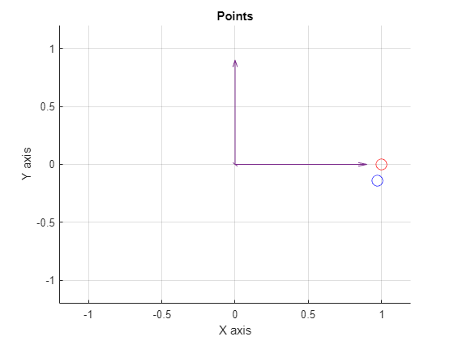

```matlab
figure;
quiver3(0,0,0,1,0,0,'Color','#7E2F8E'); hold on;
quiver3(0,0,0,0,1,0,'Color','#7E2F8E');
quiver3(0,0,0,0,0,1,'Color','#7E2F8E');
plot3(1,0,0,'ro','MarkerSize',10);
plot3(0.97,-.141,.199,'bo','MarkerSize',10);
axis([-1.2 1.2 -1.2 1.2]);
title('Points');
xlabel('X axis');
ylabel('Y axis');
zlabel('Z axis');
grid on;

view([-0.600 90.000])
```

And if we rotate with a positive angle around the y-axis (pitching up), then the new point should also have a positive Z values. Go ahead and rotate to see.

## Example 1

Let's do an example.

An aircraft is moving north at 100 ft per second, with its nose 10 degrees above the horizon. What are the body axis velocities?

First, we'll write the vector for the velocity of the aircraft in Earth reference frame

$V_E = \left[\matrix{ V_{North} \cr V_{East} \cr V_{Down} }\right] = \left[\matrix{100\cr 0\cr 0} \right]$

```matlab
V_E = [100;0;0];
```

Next, write the vector for the body axis velocities.

$V_B=\left[\matrix{u \cr v \cr w} \right]$

Next we'll calculate the rotation matrix. The angles represent the orientation of the aircraft.

```matlab
psi = 0;
theta = 10;
phi = 0;
```

Next, we'll calculate the Transform to Body from World matrix.

```matlab
psi_in_radians = deg2rad(psi);
Rz_psi = [ cos(psi_in_radians),  sin(psi_in_radians),    0;
        -sin(psi_in_radians),  cos(psi_in_radians),    0;
                           0,                    0,    1];
theta_in_radians = deg2rad(theta);
Ry_the = [cos(theta_in_radians),  0,  -sin(theta_in_radians);
                            0,  1,                       0;
        sin(theta_in_radians),  0,   cos(theta_in_radians)];
phi_in_radians = deg2rad(phi);
Rx_phi = [ 1,                    0,                    0;
         0,  cos(phi_in_radians),  sin(phi_in_radians);
         0, -sin(phi_in_radians),  cos(phi_in_radians)];
T_2BFE = Rx_phi*Ry_the*Rz_psi;
disp(T_2BFE);
```

0.984807753012208 0 -0.17364817766693 0 1 0 0.17364817766693 0 0.984807753012208

Now, we can solve for the aircraft's velocities

```matlab
V_B = T_2BFE*V_E;
disp(V_B);
```

98.4807753012208 0 17.364817766693

Let's make some sense of this

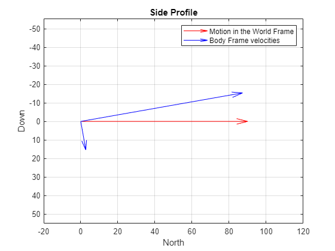

```matlab
figure;
quiver(0,0,100,0,'Color','r'); hold on;
North_vector = [V_B(1)*cos(deg2rad(10));-V_B(1)*sin(deg2rad(10))];
Down_vector = [V_B(3)*sin(deg2rad(10));V_B(3)*cos(deg2rad(10))];
quiver([0,0],[0,0],[North_vector(1),Down_vector(1)],[North_vector(2),Down_vector(2)],'Color','b');


axis([-20 120 -30 30]);
title('Side Profile');
xlabel('North');
ylabel('Down');
set(gca, 'YDir','reverse')
grid on;
axis equal;
legend('Motion in the World Frame','Body Frame velocities')
```

When we draw out the vectors, it starts to make some sense. The aircraft is pitched up and moving forward at 98.4 ft per second. But in order to prevent it from gaining altitude, it's also moving in the downward direction at 17.36 ft per second.

What happens if the aircraft was pitched up at instead?

```matlab
psi = 0;
theta = 18;
phi = 0;
```

Next, we'll calculate the Transform to Body from World matrix.

```matlab
psi_in_radians = deg2rad(psi);
Rz_psi = [ cos(psi_in_radians),  sin(psi_in_radians),    0;
        -sin(psi_in_radians),  cos(psi_in_radians),    0;
                           0,                    0,    1];
theta_in_radians = deg2rad(theta);
Ry_the = [cos(theta_in_radians),  0,  -sin(theta_in_radians);
                            0,  1,                       0;
        sin(theta_in_radians),  0,   cos(theta_in_radians)];
phi_in_radians = deg2rad(phi);
Rx_phi = [ 1,                    0,                    0;
         0,  cos(phi_in_radians),  sin(phi_in_radians);
         0, -sin(phi_in_radians),  cos(phi_in_radians)];
T_2BFE = Rx_phi*Ry_the*Rz_psi;
disp(T_2BFE);
```

0.951056516295154 0 -0.309016994374947 0 1 0 0.309016994374947 0 0.951056516295154

Now, we can solve for the aircraft's velocities

```matlab
V_B = T_2BFE*V_E;
disp(V_B);
```

95.1056516295154 0 30.9016994374947

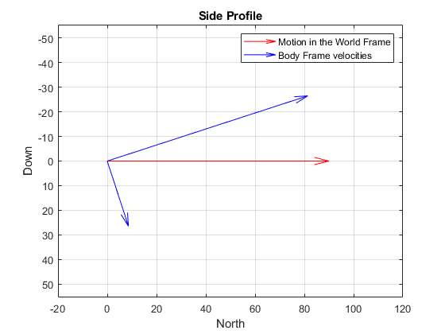

```matlab
figure;
quiver(0,0,100,0,'Color','r'); hold on;
North_vector = [V_B(1)*cos(deg2rad(18));-V_B(1)*sin(deg2rad(18))];
Down_vector = [V_B(3)*sin(deg2rad(18));V_B(3)*cos(deg2rad(18))];
quiver([0,0],[0,0],[North_vector(1),Down_vector(1)],[North_vector(2),Down_vector(2)],'Color','b');


axis([-20 120 -30 30]);
title('Side Profile');
xlabel('North');
ylabel('Down');
set(gca, 'YDir','reverse')
grid on;
axis equal;
legend('Motion in the World Frame','Body Frame velocities')
```

As you would expect, if we were pitched up more, we would have a larger downward body velocity to compensate to ensure that we're travelling strictly northward with no change in altitude in the Earth frame.

## Example 2

An aircraft is moving forward at 100 ft per second, with a heading of 230 degrees and its nose 5 degrees below the horizon.

What are the velocities of the aircraft in the Earth frame?

Set up what we know:

```matlab
V_B = [100;0;0];
psi = 230;
theta = -5;
phi = 0;
```

Calculate the Transform to BODY from EARTH

```matlab
psi_in_radians = deg2rad(psi);
Rz_psi = [ cos(psi_in_radians),  sin(psi_in_radians),    0;
        -sin(psi_in_radians),  cos(psi_in_radians),    0;
                           0,                    0,    1];
theta_in_radians = deg2rad(theta);
Ry_the = [cos(theta_in_radians),  0,  -sin(theta_in_radians);
                            0,  1,                       0;
        sin(theta_in_radians),  0,   cos(theta_in_radians)];
phi_in_radians = deg2rad(phi);
Rx_phi = [ 1,                    0,                    0;
         0,  cos(phi_in_radians),  sin(phi_in_radians);
         0, -sin(phi_in_radians),  cos(phi_in_radians)];
T_2BFE = Rx_phi*Ry_the*Rz_psi;
```

Next, calculate the Transform to EARTH from BODY

```matlab
T_2EFB = T_2BFE';
```

Now we can solve for the aircraft's motion over Earth

```matlab
V_E = T_2EFB*V_B;
disp(V_E);
```

-64.0341608768797 -76.312941273777 8.71557427476582

Does this make sense?

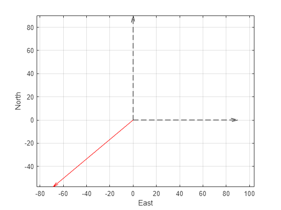

```matlab
figure;
quiver(0,0,100,0,'k--'); hold on;
quiver(0,0,0,100,'k--');
quiver(0,0,V_E(2),V_E(1),'r');
xlabel('East');
ylabel('North');
grid on;
axis equal;
```

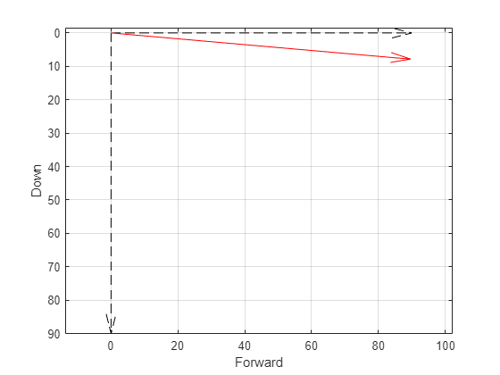

```matlab
figure;
quiver(0,0,100,0,'k--'); hold on;
quiver(0,0,0,100,'k--');
quiver(0,0,99.62,V_E(3),'r');
xlabel('Forward');
ylabel('Down');
set(gca, 'YDir','reverse')
grid on;
axis equal;
```